# Phân tích dữ liệu Bayesian - IUH.

### Bài 2.

*(bài tập tính điểm cộng)* Cho một $1000$ sản phẩm và có $10$ cái bị hỏng. Một người bốc lần lượt ra $10$ lần, mỗi lần một sản phẩm. Tính xác suất để lần thứ $10$ thu được sản phẩm hỏng.

```python
import scipy.special as sp
kq = 0
for i in range(9):
    kq += (10-i)/(1000-i)*sp.binom(9,i)/(2**9)
kq
```

```
0.005520633157513778
```

### Bài 3.

Có một căn bệnh covid có xác suất nhiễm là $0.1$. Một người tiến hành một xét nghiệm với hai sai lầm loại $I, II$ lần lượt là $0.02$ và $0.03.$ Một người thực hiện $10$ xét nghiệm và có kết quả âm tính, dương tính được cho bởi dãy $$+, +, -, +, -, -, +, -, -, -$$ Hãy thiết lập công thức để tính ra dãy xác suất mắc bệnh của người này qua từng đợt xét nghiệm.

```python
X = ['+', '+' , '-' , '+' , '-' , '-', '+' , '-', '-', '-']
d = 0.1
d_ = 1-d
pos = 0.02
neg = 0.03
for x in X:
    if x == '+':
        d = (1-neg)*d /((1-neg)*d + pos*d_)
        d_ = 1-d
    else:
        d = neg*d / (neg*d + (1-pos)*d_)
        d_ = 1-d
    print(round(d,5))
```

```
0.84348
0.99619
0.8889
0.99743
0.92235
0.26667
0.94634
0.3506
0.01626
0.00051
```

```python
def cal(n, c, d, num):
    if(num == 0):
        return d/n
    return c/n * cal(n-1, c-1, d, num-1) + d/n * cal(n-1, c, d-1, num-1)

cal(1000, 990, 10, 10)
```

```
0.01
```

```python
10/1000*9/999 + 990/1000*10/999
```

```
0.010000000000000002
```

### Bài 4.

Cho một danh sách xác suất bắn trúng mục tiêu của $n$ xạ thủ là $p_1, p_2, ..., p_n$ với các số $p_i \in (0;1), \, \forall i = 1,2,...,n$. Viết hàm CalculateProb nhận vào danh sách đó, tính và in ra các giá trị sau đây:

- a) Xác suất để tất cả đều bắn trúng, cho biết rằng người 1 đã bắn trúng.
- b) Xác suất để không ai bắn trúng, cho biết rằng có $n-1$ người nào đó đã không bắn trúng.
- c) Xác suất để có đúng hai người bắn trúng, cho biết rằng có ít nhất một người bắn trúng.

```python
#CODE HERE
```

### Bài 5.

Thực hiện simulation để giải bài toán sau: Chia ngẫu nhiên $13$ lá bài trong bộ bài $52$ lá cho một người, tính xác suất để người này tới trắng, tức là có $6$ đôi (cặp lá bài cùng số) hoặc một tứ quý Heo.

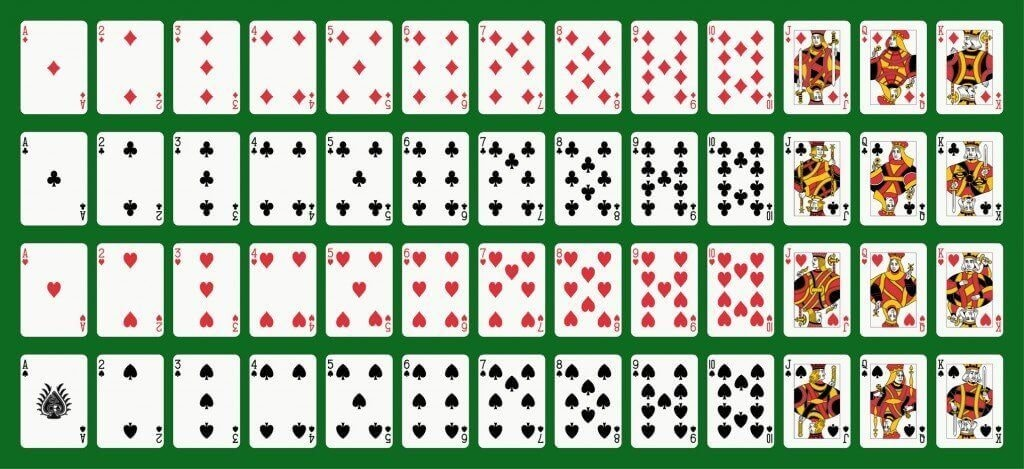

```python
#CODE HERE
```

### Bài 6.

Hãy lập công thức hoặc viết chương trình giải lại bài toán Monty Hall với số cánh cửa là $n$ tùy ý.

```python
#CODE HERE
```